# Visualization

From the analysis of the dataset twitter_archive_master. Three insights was derived:

1. Most Common dog name
2. How does the most like images affect the number of retweets.
3. The dog stage that contains the most dog

#### Insight 1. Most common dog name

As can be observed from the chart below, the most common dog name is Charlie(11) followed closely by Oliver, Cooper and Lucy(all occuring 10 times)

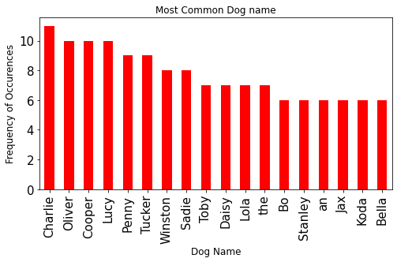

#### Insight 2. How does the most like images affects the number of retweets

As can be seen on the scatter plot below. There is a strong positive correlation(approximately 0.91) between the number of likes a dog image accumulate and the number of times the image was retweeted. This makes sense because as the number of likes on an image increase on social media platform the greater the possibility of that image been retweeted.

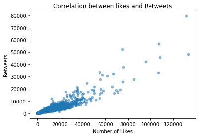

#### Insight 3. The percentage of dogs in the dog stage

Although a large portion of the dog was not properly documented into dog stages, but from the cleaned data 'pupper' is the stage most dogs in the dataset belongs as illustrated by the pie chart below,

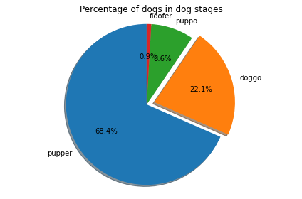